# Project: Ford GoBike System Data

## (January 2018 - December 2018)

- Introduction
- wrangling
- Cleaning
- Univariate Exploration
- Bivariate Explorationn
- Multivariate Exploration
- Summary

### by Salami Redeemer Okekale

## Introduction

> This document explores and visualizes a data set containing Ford-GoBike-System Data. There are approximately "174952" rides made in a bike-sharing system covering the greater San Francisco Bay area in the set.

## Data Wrangling

> In this step we will import all relevant python libraries needed to analysis and explore our data to know what operation we need to do to make our data clean and tidy.

## Cleaning Step

There are some quality issues that need to be cleaned :

1. missing values(start_station_id, start_station_name, end_station_id, end_station_name, member_birth_year, member_gender)
2. Start/end times are not in the timestamp format
3. The _id columns are not in object format: eg. start_station_id, end*station* & bike_id.
4. Member birth is in the float format, but needs to be converted to integer format.

### The main feature(s) of interest in the dataset.

> There many features that be explored. However, from the preliminary investigations, the main features are centered around the start and end of a ride. Since this can be used to calculate when bikes are in high or low demand. There is also enough data on the demography of the users as well as their relationship with the service - casual or paying customer.

### Key features of Interest:

> The start and end times, and related time-based information and user type.

## Univariate Exploration

> In this section, Let's look at the distributions of each of our key features.

### What's the Distribution of customers by gender ?

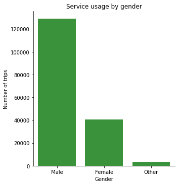

```python
# Weekday usage of the Ford bike system
gender = ['Male', 'Female', 'Other']

sb.catplot(data=df, x='member_gender', kind='count', color = color, order=gender)
label_title('Gender', 'Number of trips', 'Service usage by gender')
```

> Observation(1): Males patronise the service more than females do.

### What is the distribution of Service usage per week day ?

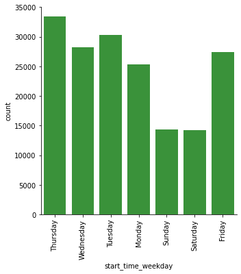

```python
sb.catplot(data=df, x='start_time_weekday', kind='count',color=color, legend_out=True).set_xticklabels(rotation=90);
label_title = ('Weekdays', 'Count', 'Monthly usage by weekday')
```

> Observation (2): Thurdays and Tuesdays are the busiest, whilst weekends are the opposite.

### What's the Service usage by hour ?

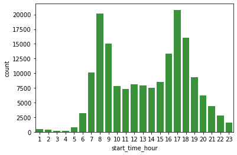

```python
# Static-ordering the bars
sb.countplot(data=df, x='start_time_hour', color=color, order=[1,2,3,4,5,6,7,8,9,10,11,12,13,14,15,16,17,18,19,20,21,22,23]);
#label_title('Hours', 'Number of Bike Riders', 'Ford GoBike System Patronage by Hour')
```

> Observation 3- In the morning, the service gets busy from about 7am, peaks at 8am and drops after 9am.

> Observation 4- In the evening, it again gets busy fron 16h, peaks 17h and drops after 18h.

> Observation 5- Two peak hours observed: 8am and 17h

### What's the age group that patronize the service most ?

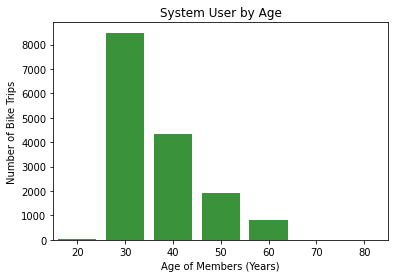

```python
# Static-ordering the bars
sb.countplot(data=df, x='Age', color=color, order=[20,30,40,50,60,70,80]);
label_title("Age of Members (Years)", "Number of Bike Trips", "System User by Age")
```

> Observation 6- Most of the users of the service are within their 30's.

### What's the majority service user type?

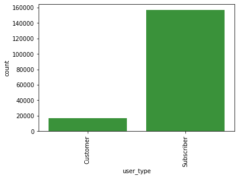

```python
# Plot the User type on a Vertical bar chart
sb.countplot(data=df, x='user_type', color=color);

# Use xticks to rotate the category labels (not axes) counter-clockwise
plt.xticks(rotation=90);
```

> Observation 8- More people are choosing to be one time subscribers than paying regular customers.

### What are the most popular destinations - start and finish - on the service and what makes them popular?

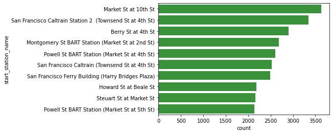

```python
# Plot the user type on a Horizontal bar chart
type_order = df['start_station_name'].value_counts().head(10).index
sb.countplot(data=df, y='start_station_name', color=color, order=type_order);
```

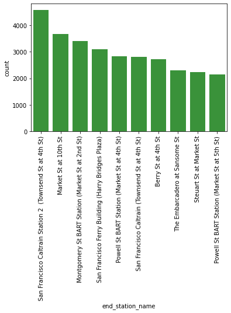

```python
# Plot the user type on a Horizontal bar chart
type_order = df['end_station_name'].value_counts().head(10).index
sb.countplot(data=df, x='end_station_name', color=color, order=type_order);
plt.xticks(rotation=90);
```

> Observation 9- The favorite start point for most users is Market St at 10th St., whilst the most end destination for most user's is at San Francisco Caltrain Station 2 (Townsend St at 4th St.)

## Bivariate Exploration

> In this section, The relationships between pairs of variables will be investigated.

### What's the relation between gender and number of trips depending on weekday ?

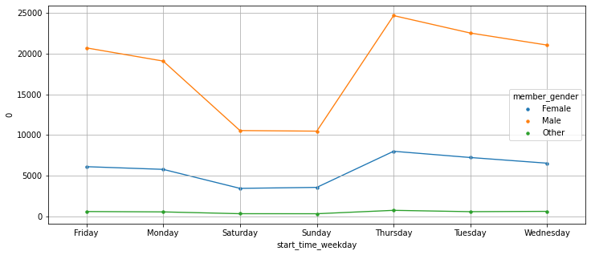

```python
# Customer Usage by Weekday vs. Subscriber Usage by Weekday
plt.figure(figsize=(12, 5))

df_user_week = df.groupby(['start_time_weekday', 'member_gender']).size().reset_index()

ax = sb.pointplot(data=df_user_week, x='start_time_weekday', y=0, hue = 'member_gender', scale=.5);

plt.grid()
```

> Observation 10- Weekends - Saturday & Sunday - are less busy across all the genders.

> Observation 11- Thurdays and Tuesdays are the busiest across all three genders.

### Which age group is likely to trip long?

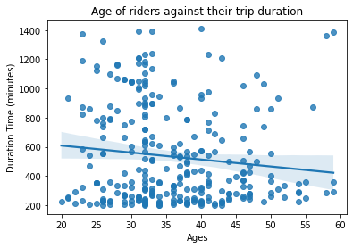

```python
df = df.query('duration_min >= 150')
sb.regplot(data = df, x = 'Age', y = 'duration_min');
label_title( "Ages", "Duration Time (minutes)","Age of riders against their trip duration")
```

> Observation 12- Person at Age 32, are likely to break the 200mins trip mark. Or they are likely to trip for longer hours.

### The relation between Age and usertype choice?

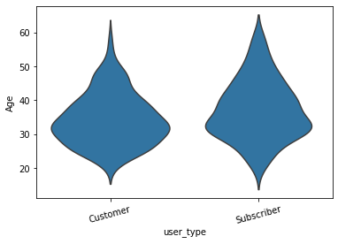

```python
base_color = sb.color_palette()[0]

# The "inner" argument represents the datapoints in the violin interior.
# It can take any value from {“box”, “quartile”, “point”, “stick”, None}
# If "box", it draws a miniature boxplot.
sb.violinplot(data=df, x='user_type', y='Age', color=base_color, inner=None)
plt.xticks(rotation=15);
```

> Observation 14- From the above visualization, it can be observed that both the customer and subcriber user types have their dominant age groups around age 31.

### What's the relation between Gender and Age ?

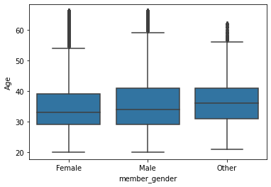

```python
# plotting box plot
sb.boxplot(data=df, x='member_gender', y='Age', color=base_color);
```

### What times do subcribers patronize the service the most?

[figure not shown]

```python
df = df.query('user_type == "Subscriber"')
sb.countplot(data = df, x = 'end_time_hour', hue='user_type', );
plt.xlabel('Hour');
plt.ylabel('Count');
```

> Observation 16: Subscribers, mostly patronize the service at 8am in the morning,when going to work and 5pm when they've closed from work.

### What is the relation user type and time of trip?

[figure not shown]

```python
sb.barplot(y='duration_min' , x='user_type' ,data=df , color=color);
label_title('User Type', 'Duration in min', 'User Type vrs Duration');
```

### Observations

> There are a lot more subscribers patronizing the system than customers. The riding habit/pattern varies a lot between subscribers and customers. Subscribers use the bike sharing system for work commnute thus most trips were on work days (Mon-Fri) and especially during rush hours (when going to work in the morning and getting off work in the afternoon), whereas customers tend to ride for fun in the afternoon or early evenings over weekends.

## Multivariate Exploration

> Plots of three or more variables to investigate the Ford Go Bike data even further.

### What is the average trip duration for all age groups at across the day?

[figure not shown]

```python
plt.figure(figsize = (16,8));
plt.scatter(data = df, x = 'start_time_hour', y = 'duration_min', c = 'Age');
plt.colorbar();
```

### What is the average trip duration variation in weekdays between customers and subscribers ?

[figure not shown]

```python
plt.figure(figsize = (16,8));
sb.pointplot(data=df, x='start_time_weekday', y='duration_min', hue='user_type', dodge=0.3, linestyles="--");
label_title('Day of Week', 'Avg. Trip Duration in Minute', 'Trip variation in different days of the week')
```

## Conclusions

### There were some features that strengthened each other in terms of looking at your feature(s) of interest.

The relationship between the various variables plotted is seen collectively and information is displayed simultaneously, strengthening some of the patterns identified in the preceding bivariate investigation as well as in the univariate research. Subscribers' efficient/short periods of consumption are consistent with their high concentration during Monday through Friday rush hours, showing that the use is mostly for commuting to work. Customers are using the bike sharing system significantly differently from subscribers, as seen by their more flexible and loose use patterns.

### There were interesting interactions between features.

The interactions between features are all supplementing each other and quite make sense when looked at combined, there's no big surprise observed. The usage habit difference between male and female is not that much or obvious throughout the exploration, which could be related to the imbalanced number of female riders/records.

## Summary

Renting a bike from the Ford Go-Bike System in San Francisco is a great way to explore the Bay Area. Subscribers and Customers use the system on weekdays at 8-9am and 5-6pm, and, occasionally around lunch time.